# Plan

At first, we learn about the data and find out which data can be useful for prediction and which data cleaning must be done to make the data usable.

The plan is as follows: 1- Explore the data and apply necessary data cleaning. 2- Train three algorithms and evaluate their performance on the validation data set. 3- Select the best performing one based on the accuracy. 4- Run the prediction on the testing data set.

# Required libraries

To run this project, the following libraries are required.

```r
library(readr)
library(dplyr)
library(caret)
```

```r
library(rpart)
library(rpart.plot)
library(RColorBrewer)
library(corrplot)
library(rattle)
```

# Loading data

We load the training and testing data to “training” and “testing” streams.

```r
training <- read_csv("pml-training.csv")
testing <- read_csv("pml-testing.csv")
```

# Exploring the dimensions of data

```r
dim(training)
```

```
## [1] 19622   160
```

```r
dim(testing)
```

```
## [1]  20 160
```

We can see that both training and testing files have 160 columns. The training set has 19622 rows, while the testing set has 20 rows.

# Returning the first part of the data

```r
head(training)
```

| X1 | user_name | raw_timestamp_part_1 | raw_timestamp_part_2 | cvtd_timestamp | new_window | num_window | roll_belt | pitch_belt | yaw_belt | total_accel_belt | kurtosis_roll_belt | kurtosis_picth_belt | kurtosis_yaw_belt | skewness_roll_belt | skewness_roll_belt.1 | skewness_yaw_belt | max_roll_belt | max_picth_belt | max_yaw_belt | min_roll_belt | min_pitch_belt | min_yaw_belt | amplitude_roll_belt | amplitude_pitch_belt | amplitude_yaw_belt | var_total_accel_belt | avg_roll_belt | stddev_roll_belt | var_roll_belt | … |
| --- | --- | --- | --- | --- | --- | --- | --- | --- | --- | --- | --- | --- | --- | --- | --- | --- | --- | --- | --- | --- | --- | --- | --- | --- | --- | --- | --- | --- | --- | --- |
| 1 | carlitos | 1323084231 | 788290 | 05/12/2011 11:23 | no | 11 | 1.41 | 8.07 | -94.4 | 3 | NA | NA | NA | NA | NA | NA | NA | NA | NA | NA | NA | NA | NA | NA | NA | NA | NA | NA | NA | … |
| 2 | carlitos | 1323084231 | 808298 | 05/12/2011 11:23 | no | 11 | 1.41 | 8.07 | -94.4 | 3 | NA | NA | NA | NA | NA | NA | NA | NA | NA | NA | NA | NA | NA | NA | NA | NA | NA | NA | NA | … |
| 3 | carlitos | 1323084231 | 820366 | 05/12/2011 11:23 | no | 11 | 1.42 | 8.07 | -94.4 | 3 | NA | NA | NA | NA | NA | NA | NA | NA | NA | NA | NA | NA | NA | NA | NA | NA | NA | NA | NA | … |
| 4 | carlitos | 1323084232 | 120339 | 05/12/2011 11:23 | no | 12 | 1.48 | 8.05 | -94.4 | 3 | NA | NA | NA | NA | NA | NA | NA | NA | NA | NA | NA | NA | NA | NA | NA | NA | NA | NA | NA | … |
| 5 | carlitos | 1323084232 | 196328 | 05/12/2011 11:23 | no | 12 | 1.48 | 8.07 | -94.4 | 3 | NA | NA | NA | NA | NA | NA | NA | NA | NA | NA | NA | NA | NA | NA | NA | NA | NA | NA | NA | … |
| 6 | carlitos | 1323084232 | 304277 | 05/12/2011 11:23 | no | 12 | 1.45 | 8.06 | -94.4 | 3 | NA | NA | NA | NA | NA | NA | NA | NA | NA | NA | NA | NA | NA | NA | NA | NA | NA | NA | NA | … |

The training set contains a number of columns with a large number of missing (NA) values. We will remove columns with over 90% NA’s from both the training and testing sets as they don’t add any value for model prediction. In addition, the first seven columns will be removed since they are either ID variables or date/time stamp related.

# Cleaning data

```r
training <- training[,-c(1:7)]
testing <- testing[,-c(1:7)]

varsNA <- sapply(training, function(x) mean(is.na(x))) > 0.9
training <- training[,varsNA==FALSE]
testing  <- testing[,varsNA==FALSE]
```

```r
dim(training)
```

```
## [1] 19622    53
```

```r
dim(testing)
```

```
## [1] 20 53
```

As we can see, we have left with 53 columns after the cleaning.

# Spliting the training set into a sub-training (70%) and testing(30%) set

```r
set.seed(1)
inTrain <- createDataPartition(y=training$classe, p=0.7, list=FALSE)
training_sub <- training[inTrain,]
testing_sub <- training[-inTrain,]
```

# Building models

# Support vector machine (SVM)

# Training model

```r
set.seed(1)
modFit1<-train(classe~.,method="svmRadial",data=training_sub)
```

# Estimating the performance of the SVM on the validation data set.

```r
predictSVM <- predict(modFit1, testing_sub)
```

# Confusion matrix

```r
confusionMatrix(table(testing_sub$classe, predictSVM))
```

```
## Confusion Matrix and Statistics
##
##    predictSVM
##        A    B    C    D    E
##   A 1653    5   15    1    0
##   B  119  968   49    0    3
##   C    5   51  948   21    1
##   D    4    0   91  867    2
##   E    1   25   38   30  988
##
## Overall Statistics
##
##                Accuracy : 0.9217
##                  95% CI : (0.9145, 0.9284)
##     No Information Rate : 0.3028
##     P-Value [Acc > NIR] : < 2.2e-16
##
##                   Kappa : 0.9007
##
##  Mcnemar's Test P-Value : NA
##
## Statistics by Class:
##
##                      Class: A Class: B Class: C Class: D Class: E
## Sensitivity            0.9276   0.9228   0.8309   0.9434   0.9940
## Specificity            0.9949   0.9646   0.9836   0.9805   0.9808
## Pos Pred Value         0.9875   0.8499   0.9240   0.8994   0.9131
## Neg Pred Value         0.9694   0.9829   0.9603   0.9894   0.9988
## Prevalence             0.3028   0.1782   0.1939   0.1562   0.1689
## Detection Rate         0.2809   0.1645   0.1611   0.1473   0.1679
## Detection Prevalence   0.2845   0.1935   0.1743   0.1638   0.1839
## Balanced Accuracy      0.9612   0.9437   0.9072   0.9619   0.9874
```

## Visualization

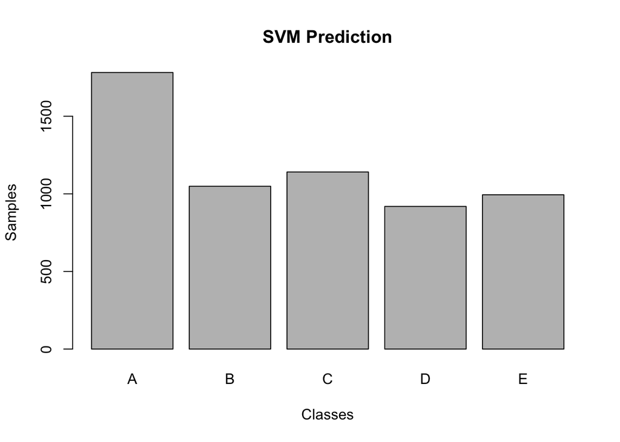

```r
plot(predictSVM, main="SVM Prediction", ylab="Samples", xlab="Classes")
```

# Gradient Boosted Machines (GBM)

# Training model

```r
modFit2<-train(classe~.,method="gbm",data=training_sub)
```

# Estimating the performance of the GBM on the validation data set.

```r
predictGBM <- predict(modFit2, testing_sub)
```

# Confusion matrix

```r
confusionMatrix( table(testing_sub$classe, predictGBM))
```

```
## Confusion Matrix and Statistics
##
##    predictGBM
##        A    B    C    D    E
##   A 1632   28   11    1    2
##   B   34 1074   30    0    1
##   C    0   35  969   17    5
##   D    0    4   32  920    8
##   E    2   12    6   22 1040
##
## Overall Statistics
##
##                Accuracy : 0.9575
##                  95% CI : (0.952, 0.9625)
##     No Information Rate : 0.2834
##     P-Value [Acc > NIR] : < 2.2e-16
##
##                   Kappa : 0.9463
##
##  Mcnemar's Test P-Value : 4.656e-05
##
## Statistics by Class:
##
##                      Class: A Class: B Class: C Class: D Class: E
## Sensitivity            0.9784   0.9315   0.9246   0.9583   0.9848
## Specificity            0.9900   0.9863   0.9882   0.9911   0.9913
## Pos Pred Value         0.9749   0.9429   0.9444   0.9544   0.9612
## Neg Pred Value         0.9915   0.9834   0.9837   0.9919   0.9967
## Prevalence             0.2834   0.1959   0.1781   0.1631   0.1794
## Detection Rate         0.2773   0.1825   0.1647   0.1563   0.1767
## Detection Prevalence   0.2845   0.1935   0.1743   0.1638   0.1839
## Balanced Accuracy      0.9842   0.9589   0.9564   0.9747   0.9881
```

# Visualization

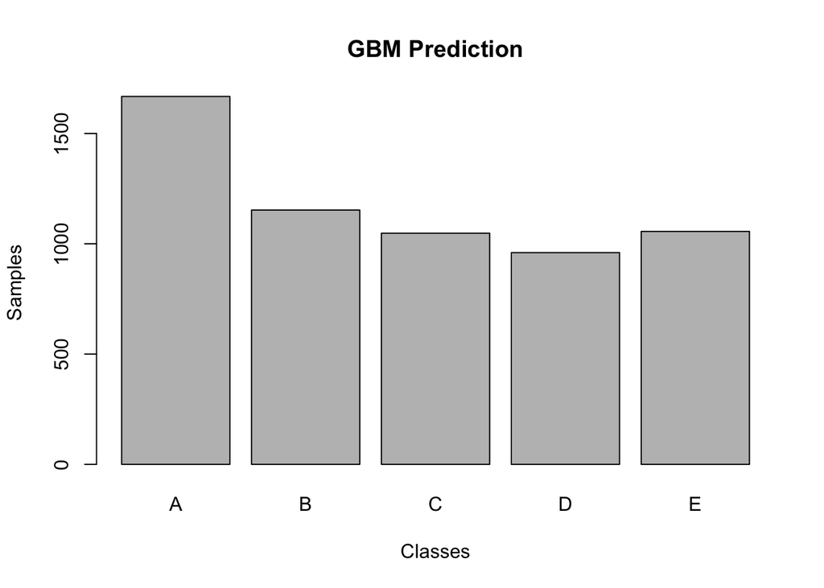

```r
plot(predictGBM, main="GBM Prediction", ylab="Samples", xlab="Classes")
```

# Training model

```r
modFit3<-train(classe~.,method="rf",data=training_sub)
```

# Estimating the performance of the RF on the validation data set.

```r
predictRF <- predict(modFit3, testing_sub)
```

# Confusion matrix

```r
confusionMatrix( table(testing_sub$classe, predictRF ) )
```

```
## Confusion Matrix and Statistics
##
##    predictRF
##        A    B    C    D    E
##   A 1670    3    1    0    0
##   B    3 1135    0    1    0
##   C    0    9 1010    7    0
##   D    0    0   14  949    1
##   E    0    2    0    3 1077
##
## Overall Statistics
##
##                Accuracy : 0.9925
##                  95% CI : (0.99, 0.9946)
##     No Information Rate : 0.2843
##     P-Value [Acc > NIR] : < 2.2e-16
##
##                   Kappa : 0.9905
##
##  Mcnemar's Test P-Value : NA
##
## Statistics by Class:
##
##                      Class: A Class: B Class: C Class: D Class: E
## Sensitivity            0.9982   0.9878   0.9854   0.9885   0.9991
## Specificity            0.9991   0.9992   0.9967   0.9970   0.9990
## Pos Pred Value         0.9976   0.9965   0.9844   0.9844   0.9954
## Neg Pred Value         0.9993   0.9971   0.9969   0.9978   0.9998
## Prevalence             0.2843   0.1952   0.1742   0.1631   0.1832
## Detection Rate         0.2838   0.1929   0.1716   0.1613   0.1830
## Detection Prevalence   0.2845   0.1935   0.1743   0.1638   0.1839
## Balanced Accuracy      0.9986   0.9935   0.9910   0.9927   0.9990
```

## Visualization

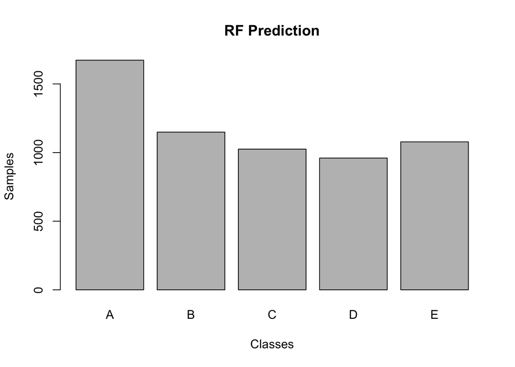

```r
plot(predictRF, main="RF Prediction", ylab="Samples", xlab="Classes")
```

# Predicting for testing set

The Random Forests has the best accuracy, therefore, this model will be used on the testing data.

```r
pred <- predict(modFit3, testing)
```

# Prediction of the 20 cases

```r
pred
```

```
##  [1] B A B A A E D B A A B C B A E E A B B B
## Levels: A B C D E
```